# Case Sparsity

RK

June 17, 2017

# Rundown for Meeting with John on 2017-06-20

## Background

This year, there have been 758 confirmed cases of yellow fever in Brazil, more than ten times the maximum number of cases per year since 2000. Furthermore, the majority of these cases fall outside the previous geographic area of vaccine recommendation (it has since been updated), suggesting that transmission here was relatively unexpected, and perhaps due in part to the existence of a naive, unvaccinated population (although we do not have vaccination data to support this hypothesis).

## Question: What municipalities in Brazil are most at risk of yellow fever outbreaks?

We’d like to approach this from a risk map or suitability perspective, resulting in a heatmap by month of risk of YF cases.

## Data

**Epidemiological Data**

- Number of cases by month per municipality (referred to as muni) from 2001-2014
- Positive municipalites (not case number) during 2017 outbreak at three time points (Jan, March, May)

**Environmental Data**

- Land Cover by year/1km resolution, aggregated to muni
- Temperature (min, mean, max) by month/1km resolution, aggregated to muni
- NDVI by month/1km resolution, aggregated to muni
- Precipiation by month/4km, aggregated to muni
- Tree Cover Loss from 2000-2014 (not yearly) for 30x30m pixels

**Socio-demographic Data**

- Population by muni/year
- income by muni/year

## Why this meeting?

We now have all this data, and want some guidance on where to go from here and how to visualize and interpret our data to choose a model approach. We imagine this will depend on some characteristics of our dataset, particularly sparseness.

# Data run down

# Exploring the distribution of Yellow Fever

We’d like to know how sparse the data is, so I will answer the following:

```
- number of positive observations
- average number of cases per year & total cases (overall and by year)
- number of unique municipalities with cases
- number of municipalities with multiple positive months (grouped by months, ie those with 2, those with 3, etc.)
- number of municipalities that never have a yellow fever case
- when a municipality is positive, the range, mean, median of the number of cases it has during that month
```

## Temporal breakdown

Plot of the entire timeseries. Months with no cases are not plotted. Of the 168 months, only 49 months had any reported cases. A majority of those months only had a single case reported. A total of 212 cases were reported over the 14 year period.

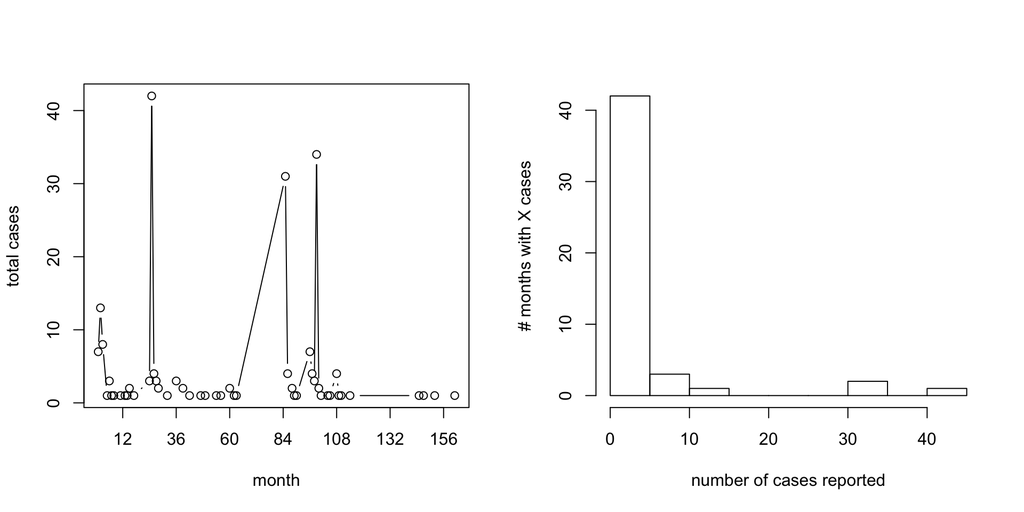

### By year

There were no cases reported in 2007, 2011, and 2012. A majority of years had fewer than 10 cases. Years with fewer cases also had fewer infected municipalities.

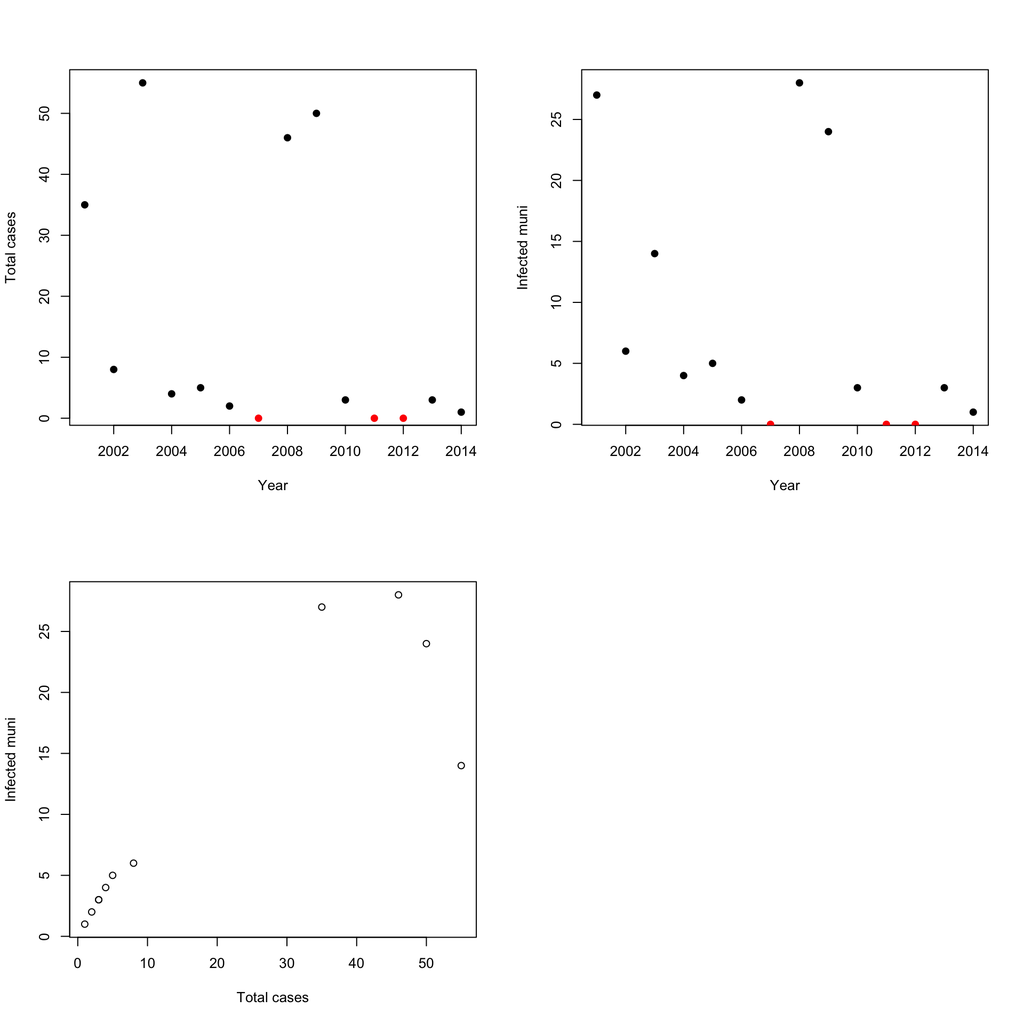

### By calendar month

We can look at the number of cases by month to get at any seasonal trends. December through March has an increase of cases, but when the number of municipalities infected are also taken into account the ave case per month is still very low. January has the most number of infected municipalities over the 14 year timeseries.

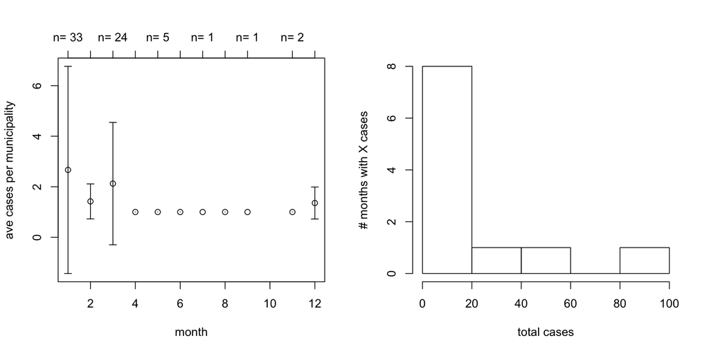

## Spatial Breakdown

From the 5564 municipalities, 78 municipalities had cases. Of those, 55 muni were only infected once.

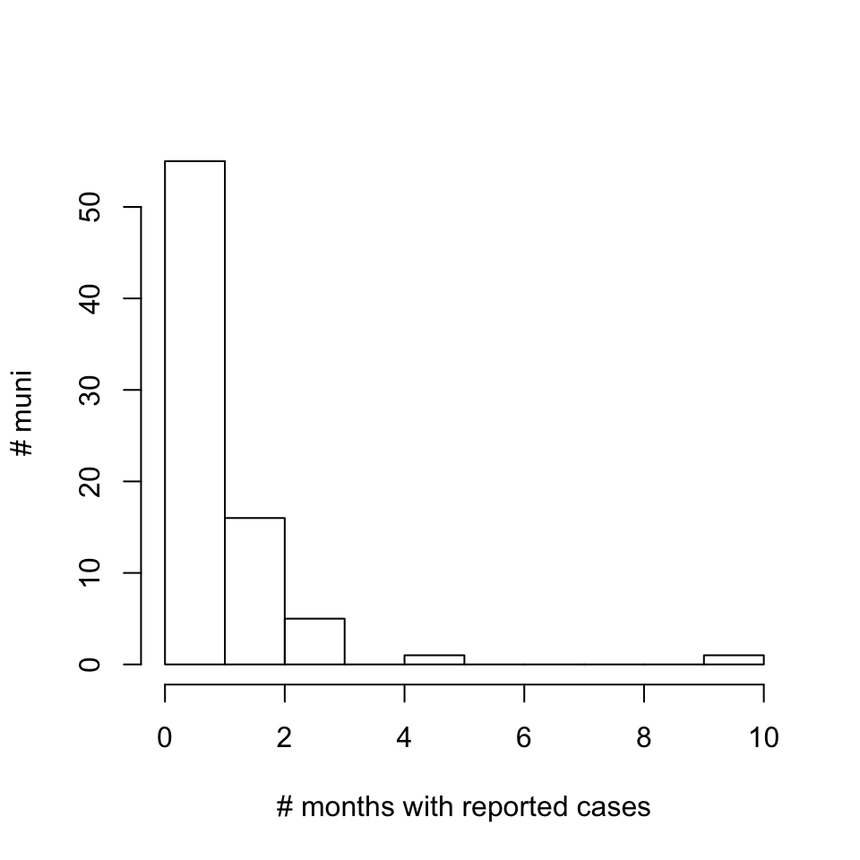

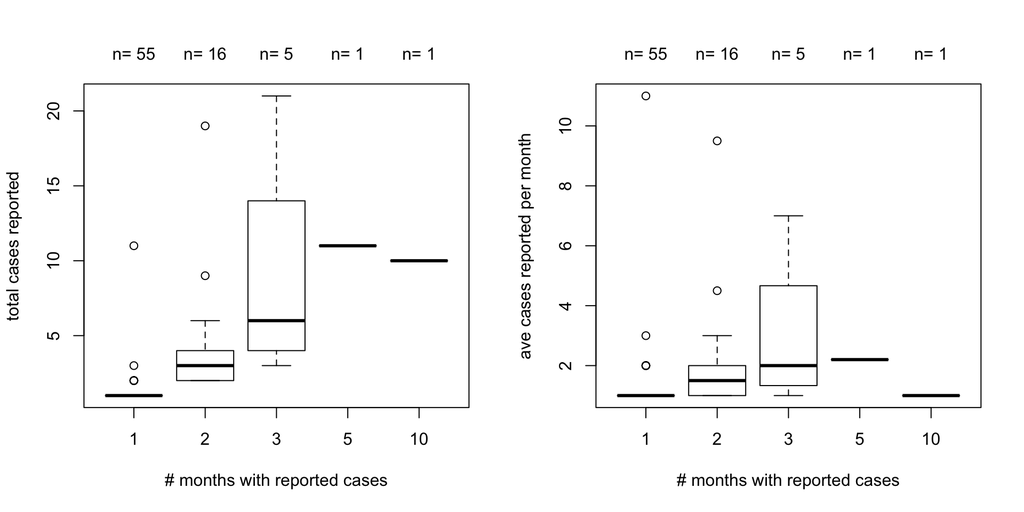

Still working on consecutive months infected and spatial relationship to other infected muni.

## Recap

I think it is safe to conclude that the data is very sparse:

[output not shown]